# Barack Obama

Pradeep Adhokshaja

26 October 2016

## Libraries

The tools to load are as follows.

```r
library(dplyr)
```

```r
library(plotly)
library(stringr)
library(knitr)
library(tidyr)
library(broom)
library(RSentiment)
library(tidytext)
library(tm)
library(igraph)
library(data.table)
library(widyr)
#library(ggraph)
```

Let’s explore the Tweets produced by President Obama.

## Importing the Data

Taking care of the NA values that have been introduced.

```r
for(i in 1:dim(obama)[1])
{
  if(is.na(obama$year[i]))
  {
    obama$year[i]<-2016
  }
}

obama$month[1:4] <- 'Oct'
for(i in 5:427)
{
  obama$month[i]<- str_sub(obama$date[i],1,3)
}
#df$Month.Name <- factor( df$Month.Name, levels = c( "Apr", "May", ..., "Feb", "Mar" ) )
obama$month <- factor(obama$month,levels=c('Jan','Feb','Mar','Apr','May','Jun','Jul','Aug','Sep','Oct','Nov','Dec'))
```

## Total Tweets by Year and Month

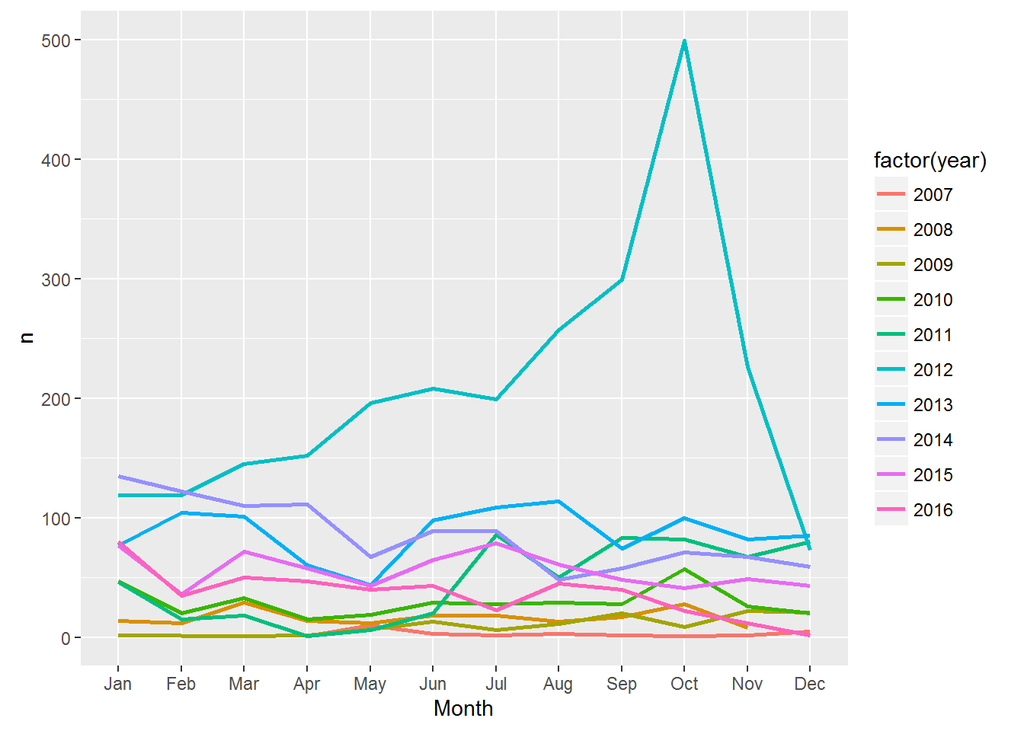

```r
obama %>% group_by(year,month) %>% summarise(n=n()) %>%
  ggplot(aes(x = month, y =n) ) +
     geom_line(aes(group = year, colour = factor(year)),size=1) +
     scale_x_discrete(name = "Month" ) +
     scale_y_continuous()
```

```r
ggplotly()
```

[interactive chart not shown]

The year 2012 seems to be the year President Obama has engaged with Twitter a lot.This could be due to the Presidential elections in 2012. He was standing against Mitt Romney.

## Number of Hashtags.

```r
obama$hashtags <-(str_extract_all(obama$text, "#\\S+"))
obama$num_hashtag <- rep(0,dim(obama)[1])
for(i in 1:dim(obama)[1])
{
  obama$num_hashtag[i] <- length(unlist(obama$hashtags[i]))

}
```

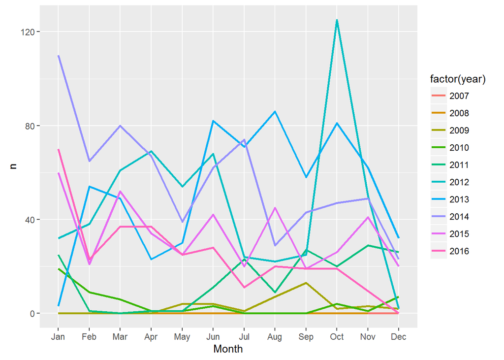

```r
obama %>% group_by(year,month) %>% summarise(n=sum(num_hashtag)) %>%
  ggplot(aes(x=month,y=n))+
  geom_line(aes(group=year,colour=factor(year)),size=1)+
  scale_x_discrete(name="Month")+
  scale_y_continuous()
```

```r
ggplotly()
```

[interactive chart not shown]

The number of hashtags used seems to be haphazard. There is a spike in the number of hashtags used in 2012 in the month of October, before the Presidential Election on 6th November 2012. What were the most popular hashtags

```r
df <- data.frame(hashtag = unlist(obama$hashtags))
kable(df %>% group_by(hashtag) %>% summarise(n=n()) %>% arrange(desc(n)) %>% filter(n>10))
```

| hashtag | n |
| --- | --- |
| #SOTU | 125 |
| #ActOnClimate | 108 |
| #Obama2012 | 90 |
| #RaiseTheWage | 73 |
| #progress | 60 |
| #OpportunityForAll | 52 |
| #Obamacare | 46 |
| #DontDoubleMyRate | 40 |
| #CollegeOpportunity | 35 |
| #ABetterBargain | 34 |
| #immigration | 33 |
| #EnoughAlready | 30 |
| #ImmigrationAction | 30 |
| #Forward2012 | 26 |
| #hc09 | 23 |
| #MadeInAmerica | 23 |
| #ACA | 22 |
| #BuffettRule | 22 |
| #GetCovered | 22 |
| #DinnerWithBarack | 21 |
| #LoveIsLove | 21 |
| #climate | 20 |
| #Obamacare, | 17 |
| #SCOTUS | 17 |
| #EqualPay | 16 |
| #StandWithWomen | 16 |
| #DoYourJob | 14 |
| #Forward | 14 |
| #RebuildAmerica | 14 |
| #ActOnReform | 13 |
| #LoveWins | 13 |
| #WeDemandAVote | 13 |
| #ActOnClimate. | 12 |
| #ActOnJobs | 12 |
| #ImmigrationReform | 12 |
| #IranDeal | 12 |
| #DemandAction | 11 |
| #GetCoveredNow | 11 |
| #MLKDream50 | 11 |
| #RegToVote | 11 |
| #RenewUI | 11 |
| #Selma50 | 11 |
| #Women2012 | 11 |

## Sentiment scores

```r
tweet <- obama$text
tweet = gsub("(f|ht)(tp)(s?)(://)(.*)[.|/](.*)", " ", tweet)
#retweet
tweet = gsub("(RT|via)((?:\\b\\W*@\\w+)+)", " ", tweet)
# removing hashtags
tweet = gsub("#\\w+", " ", tweet)
# removing @people
tweet = gsub("@\\w+", " ", tweet)
#removing punctuations
tweet = gsub("[[:punct:]]", " ", tweet)
#removing numbers
tweet = gsub("[[:digit:]]", " ", tweet)
#removing emojis
tweet<-str_replace_all(tweet,"[^[:graph:]]"," ")
tweet <- str_replace_all(tweet,'https'," ")
tweet <- str_replace_all(tweet,'amp'," ")
# removing non-english characters
#tweet1 <- grep('tweet',iconv(tweet,'latin1','ASCII',sub='tweet'))
obama$text_clean <- tweet
obama$sentiment <- rep("",dim(obama)[1])
for(i in 1:dim(obama)[1])
{
  obama$sentiment[i] <- as.character(calculate_sentiment(obama$text_clean[i])$sentiment)
}
```

### Sentiments by Year

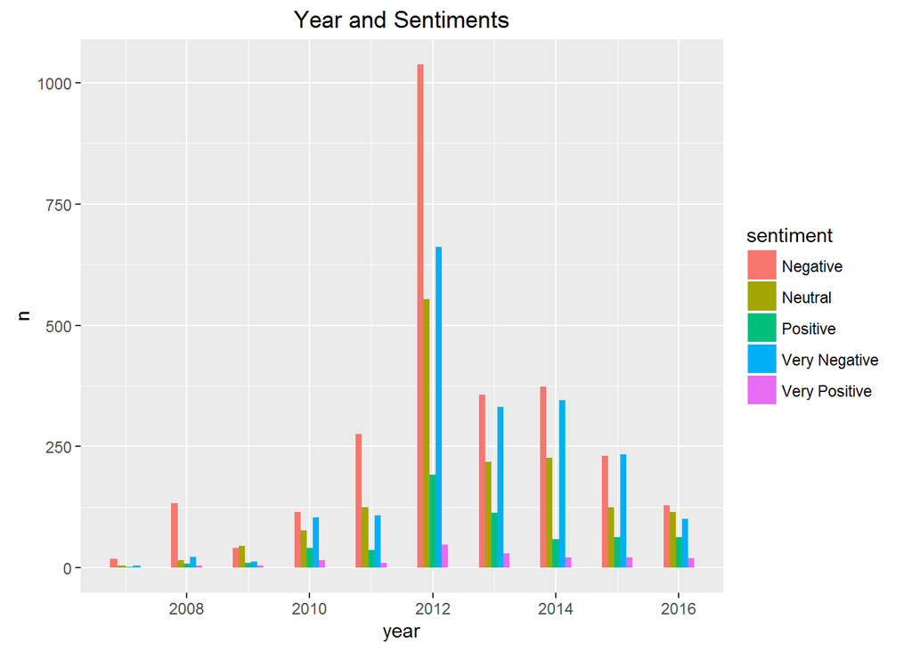

```r
obama %>% group_by(year,sentiment) %>% summarise(n=n()) %>%
  ggplot(aes(x=year,y=n,fill=sentiment))+
  geom_bar(stat='identity',width=0.5,position = 'dodge')+
  ggtitle("Year and Sentiments")
```

### Sentiments by Month

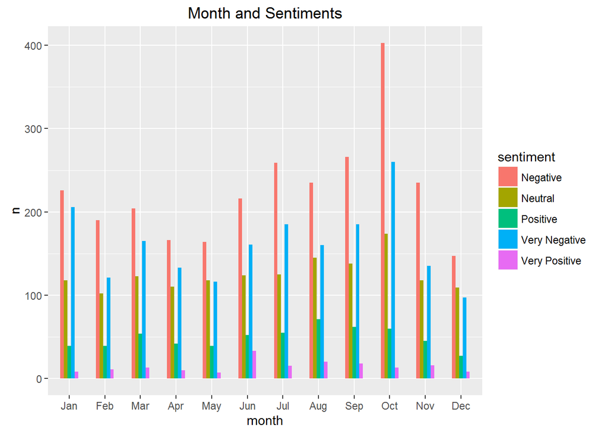

```r
obama %>% group_by(month,sentiment) %>% summarise(n=n()) %>%
  ggplot(aes(x=month,y=n,fill=sentiment))+
  geom_bar(stat='identity',width=0.5,position = 'dodge')+
  ggtitle("Month and Sentiments")
```

We see that a large portion of the tweets were negative in nature.The number of tweets spiked up in the year 2012. The highest number Tweets with very positive sentiments are also in 2012. The month October had the highest number of Tweets overall. This could be attributed to the last month before the Presidential Elections

## Frequent Terms Used in each year

```r
text_2016 <- subset(obama,year==2016)$text_clean
text_2015 <- subset(obama,year==2015)$text_clean
text_2014 <- subset(obama,year==2014)$text_clean
text_2013 <- subset(obama,year==2013)$text_clean
text_2012 <- subset(obama,year==2012)$text_clean
text_2011 <- subset(obama,year==2011)$text_clean
text_2010 <- subset(obama,year==2010)$text_clean
text_2009 <- subset(obama,year==2009)$text_clean
text_2008 <- subset(obama,year==2008)$text_clean
text_2007 <- subset(obama,year==2007)$text_clean

frequent_words_plot <- function(tweet,count)
{
  corp <- Corpus(VectorSource(tweet))
  corp <- tm_map(corp,removeWords,c(stopwords('english'),stopwords('SMART')))
  tdm <- TermDocumentMatrix(corp)

  freq.terms <- findFreqTerms(tdm,lowfreq = count)
  term.freq <- rowSums(as.matrix(tdm))
  term.freq <- subset(term.freq, term.freq >= count)
  df <- data.frame(term = names(term.freq), freq = term.freq)
  ggplot(df, aes(x = term, y = freq)) + geom_bar(stat = "identity") + xlab("Terms") + ylab("Count") + coord_flip()
}
```

### 2007

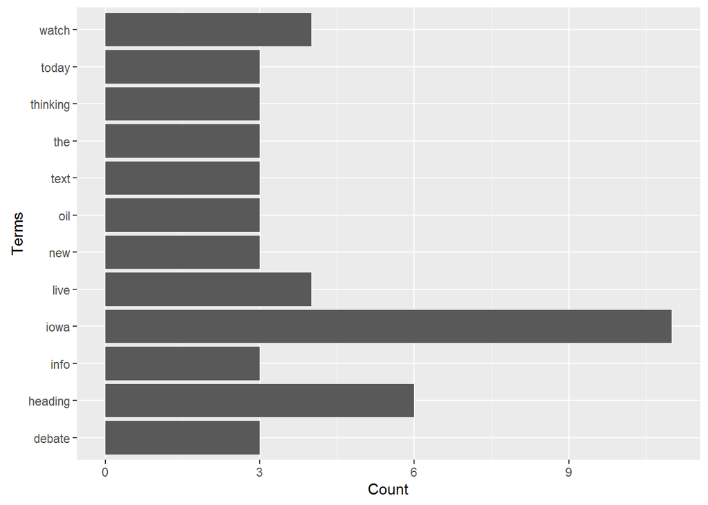

```r
frequent_words_plot(text_2007,3)
```

### 2008

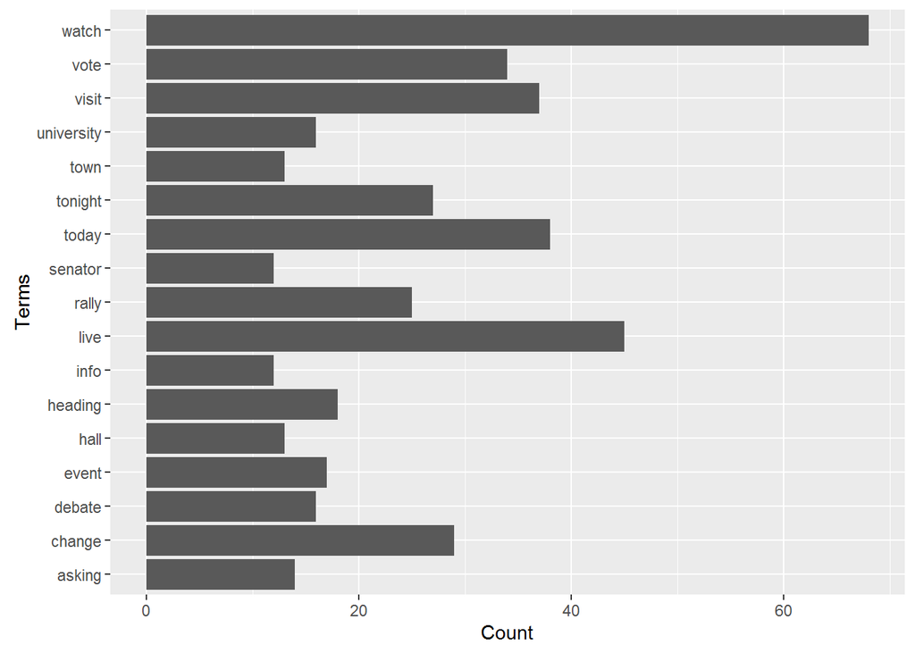

```r
frequent_words_plot(text_2008,12)
```

### 2009

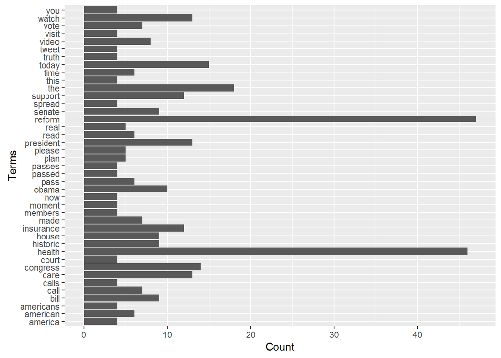

```r
frequent_words_plot(text_2009,4)
```

### 2010

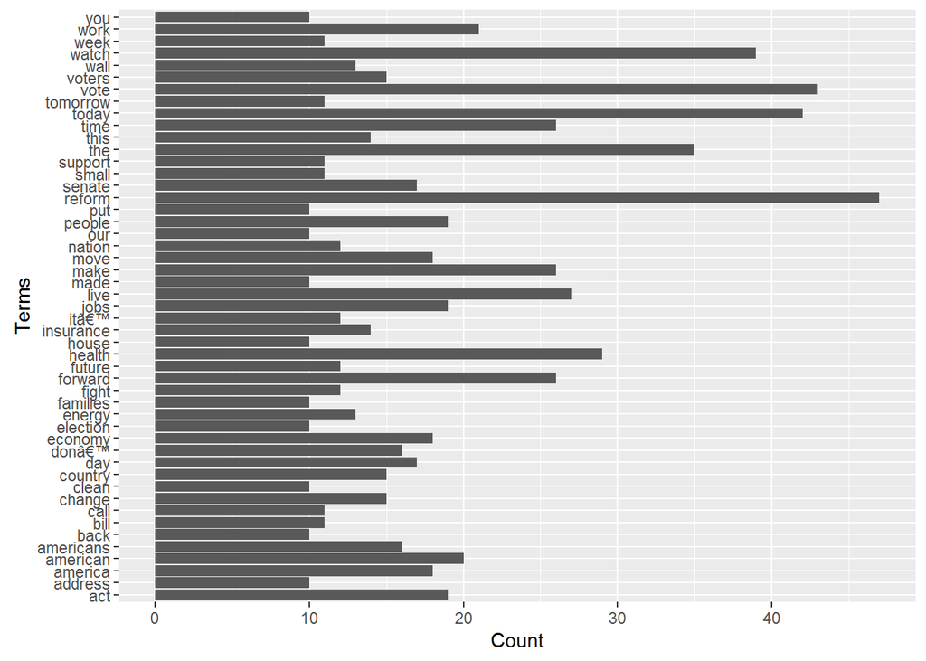

```r
frequent_words_plot(text_2010,10)
```

### 2011

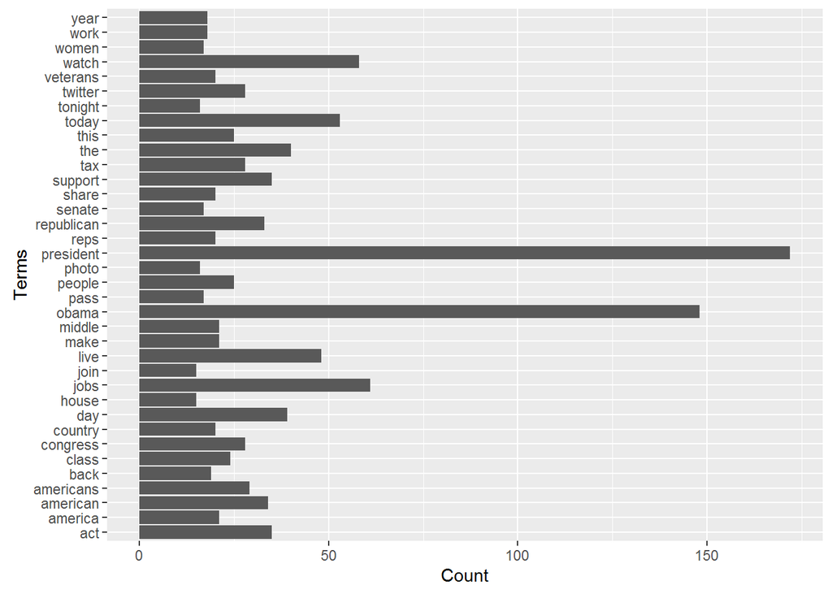

```r
frequent_words_plot(text_2011,15)
```

### 2012

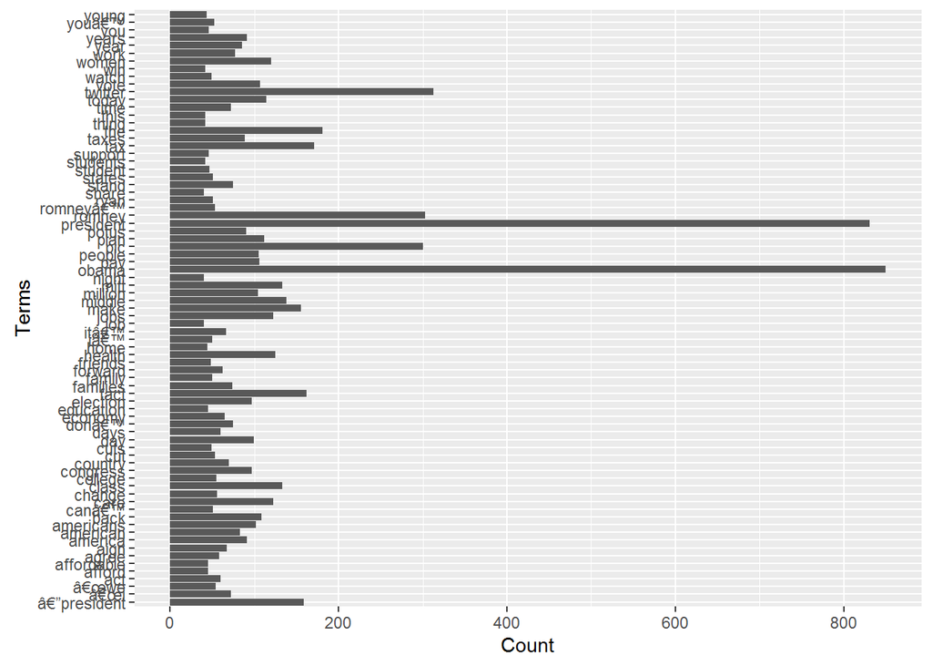

```r
frequent_words_plot(text_2012,40)
```

### 2013

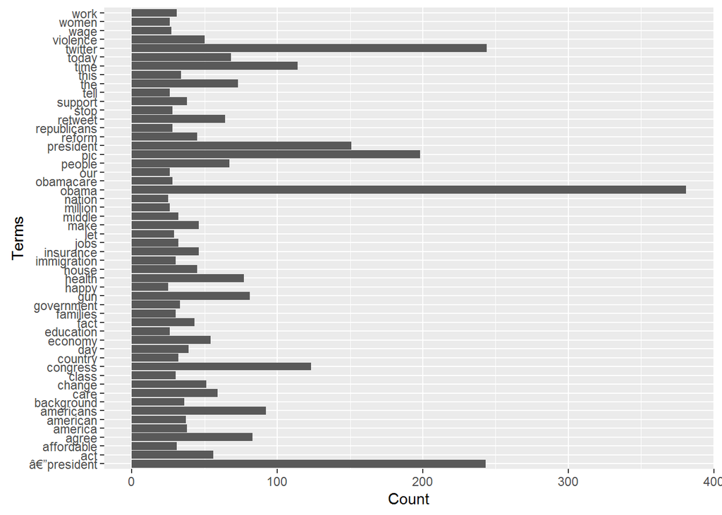

```r
frequent_words_plot(text_2013,25)
```

### 2014

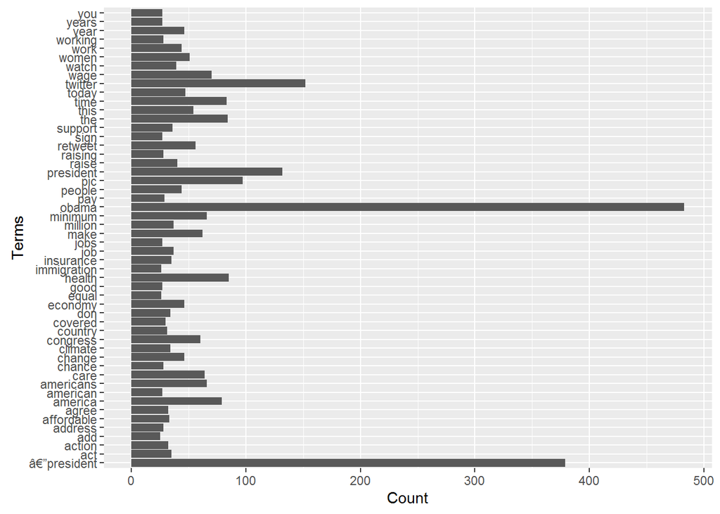

```r
frequent_words_plot(text_2014,25)
```

### 2015

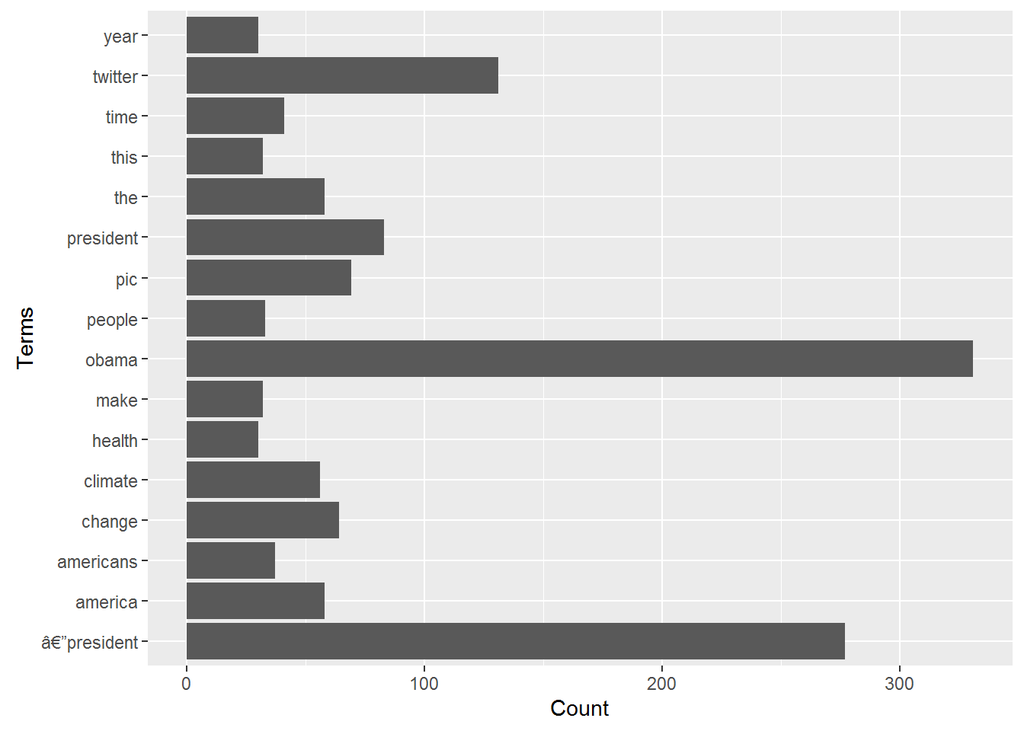

```r
frequent_words_plot(text_2015,30)
```

### 2016

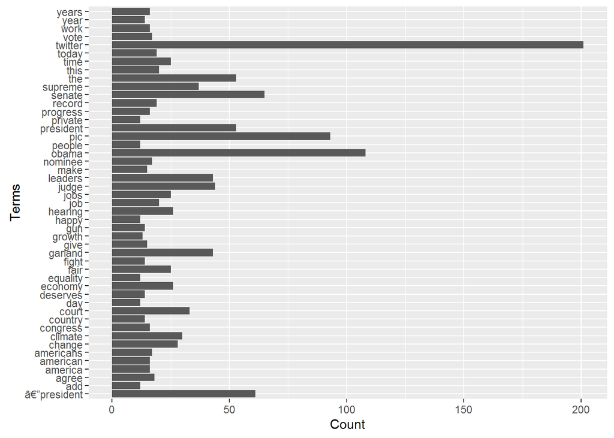

```r
frequent_words_plot(text_2016,12)
```

## Terms and Their Correlations

```r
temp <- obama[,c('X','date','month','id','text_clean','year')]

words <- temp %>%
  unnest_tokens(word,text_clean)%>%
  filter(!word %in% stop_words$word,
         str_detect(word,"^[a-z']+$"))

words_counts <- words %>%
  count(word) %>%
  filter(n >= 4)

words_correlations <- words %>%
  semi_join(words_counts) %>%
  pairwise_cor(word, X, sort = TRUE, upper = FALSE)
```

[figure not shown]

```r
set.seed(2016)
words_correlations <- filter(words_correlations,correlation>0.5)
words_correlations <- as.data.frame(words_correlations)
graph <- make_graph(t(words_correlations[,c(1:2)]),directed = F)
E(graph)$weight <- words_correlations$correlation

plot(graph,edge.width=E(graph)$weight,layout=layout.fruchterman.reingold,vertex.size = 5)
```

```r
kable(words_correlations)
```

| item1 | item2 | correlation |
| --- | --- | --- |
| boards | editorial | 1.0000000 |
| jr | luther | 1.0000000 |
| colin | powell | 1.0000000 |
| chag | sameach | 1.0000000 |
| jon | stewart | 1.0000000 |
| roe | wade | 1.0000000 |
| garland | judge | 0.9773819 |
| ledbetter | lilly | 0.9635538 |
| minimum | wage | 0.9592064 |
| parks | rosa | 0.9257526 |
| class | middle | 0.9224713 |
| court | supreme | 0.9171238 |
| carbon | pollution | 0.9129235 |
| bin | laden | 0.9128044 |
| jr | martin | 0.9128044 |
| luther | martin | 0.9128044 |
| mandela | nelson | 0.9128044 |
| hall | town | 0.9086276 |
| private | sector | 0.9044109 |
| registration | voter | 0.9044021 |
| island | rhode | 0.8943620 |
| malia | sasha | 0.8943620 |
| james | taylor | 0.8943620 |
| insider | trading | 0.8943620 |
| lands | waters | 0.8943620 |
| bumper | sticker | 0.8795613 |
| chief | commander | 0.8742193 |
| existing | pre | 0.8635600 |
| parenthood | planned | 0.8569970 |
| obama | president | 0.8318340 |

[output cut: 117 more lines]